# Top Streamed Songs of 2017 - 2019

## Introduction

Music is a complex and deeply subjective form of expression, yet certain songs manage to achieve widespread popularity, accumulating millions—or even billions—of streams. This raises an interesting question: are there measurable characteristics that contribute to a song’s success?

For this project, I investigated whether specific musical features—tempo (the speed or pace of a song) and valence (a measure of musical positivity or emotional brightness)—might be linked to a song’s popularity. While music preferences are highly individual, I was curious to see if top-streamed songs share common traits, and whether those traits have changed over time.

The focus of this analysis is on songs that charted between 2017 and 2019, and it centers around the following research questions:

Has the tempo of top-streamed songs increased from 2017 to 2019?

Is there a correlation between tempo and chart ranking?

Have songs become happier over the same period?

Although the general perception may suggest that popular music has become faster and more upbeat in recent years, the analysis did not find statistically significant evidence supporting an upward trend in either tempo or valence between 2017 and 2019.

## Background

Spotify remains one of the world’s leading audio streaming platforms. As of the end of Q2 2022, the service reported 433 million total users, including 188 million premium subscribers. Through its data collection and algorithmically generated playlists of top-streamed songs, Spotify offers an excellent foundation for analyzing music trends.

In this study, I utilize several of Spotify’s top-streamed song playlists to investigate two key research questions:

Tempo trends:

How has the average tempo of top-streamed songs changed from 2017 to 2019?

Is there a measurable correlation between tempo and chart ranking?

Valence trends:

Have top-streamed songs become more “happy” (higher valence) over the same period?

By grounding the project in Spotify’s official user and playlist metrics, I aimed for a more rigorous exploration of whether tempo and valence play a role in streaming success. Despite expectations, my analysis did not reveal statistically significant increases in either tempo or valence from 2017 to 2019.

### About the Data

To conduct this analysis, I used publicly available datasets curated by Nadin Tamer, which compile the top streamed songs on Spotify for the years 2017, 2018, and 2019. These datasets were generated using Organize Your Music, a tool that allows users to analyze musical features of Spotify playlists. By inputting Spotify’s official Top Tracks playlists into the web app, Tamer was able to extract audio feature data for each song.

The resulting datasets were uploaded to Kaggle and are accessible via the following links:

- [The Top Streamed Songs for 2017](https://www.kaggle.com/nadintamer/top-tracks-of-2017)[^1]
- [The Top Streamed Songs for 2018](https://www.kaggle.com/nadintamer/top-spotify-tracks-of-2018)[^2]
- [The Top Streamed Songs for 2019](https://www.kaggle.com/nadintamer/top-spotify-tracks-of-2019)[^3]

Each dataset includes one row per song, ordered by rank, where a lower number indicates a higher number of streams (e.g., rank 1 is the most-streamed song of the year).

Key Variables The analysis focused on three main variables: tempo, valence, and rank.

Tempo is measured in beats per minute (BPM) and reflects the speed or pace of a song. While it is represented numerically in the dataset, tempo is often categorized using Italian musical terms. For example:

Largo: 45–50 BPM (broadly)

Andante: 73–77 BPM (walking pace)

Allegro: 109–132 BPM (fast and bright)

Presto: 168–177 BPM (very fast)

For more on tempo terminology, see this guide.

Valence is a metric provided by Spotify’s API that quantifies the “positiveness” or emotional brightness of a track, on a scale from 0 to 1. A higher valence score indicates a happier, more cheerful sound, while lower scores reflect sadness or emotional intensity. Additional context on this metric can be found here and here.

Rank reflects a song’s streaming popularity within the year. A rank of 1 corresponds to the most-streamed song, rank 2 to the second most-streamed, and so on.

These features were selected to examine potential patterns in listener preferences over time, particularly around energy (tempo), mood (valence), and popularity (rank).

#### Variables from Data

Key Variables from the Spotify Top Streamed Songs Data

| Name | Description |
| --- | --- |
| name | A string of the song name |
| artists | A string of the artist(s)’ name(s) |
| valence | A real number between 0 and 1 that represents the happiness of a song |
| tempo | A real number greater than or equal to 0 that represents the speed at which a passage of music is played. It is measured in beats per minute (BPM) |
| rank | The popularity of the song for the year |

## Analysis

### Did the top streamed songs get faster from 2017 to 2019?

First, we summarize the tempo data for all three years.

Tempo Summary

| year | n | mean | sd | max | min |
| --- | --- | --- | --- | --- | --- |
| 2017 | 100 | 119.2025 | 27.95293 | 199.864 | 75.016 |
| 2018 | 100 | 119.9042 | 28.79598 | 198.075 | 64.934 |
| 2019 | 50 | 120.4257 | 28.74086 | 179.974 | 71.105 |

- $year$ is the year the songs are from
- $n$ is the number of songs
- $mean$ is the mean tempo for the given year
- $sd$ is the standard deviation of the songs’ tempo
- $max$ is the song with the fastest tempo for the year
- $min$ is the song with the slowest tempo for the year

From the table, it can be seen that the mean increases from between all three years, but is this increase statistically significant?

#### T Tests

To test this, we ran an unpaired T Test (Two Mean Test) of tempos between 2017 and 2018:

Tempo between 2017 and 2018 for Top 5 Songs

| rank | 2017 | 2018 |
| --- | --- | --- |
| 1 | 95.977 | 77.169 |
| 2 | 88.931 | 75.023 |
| 3 | 177.833 | 159.847 |
| 4 | 103.019 | 140.124 |
| 5 | 80.924 | 91.030 |

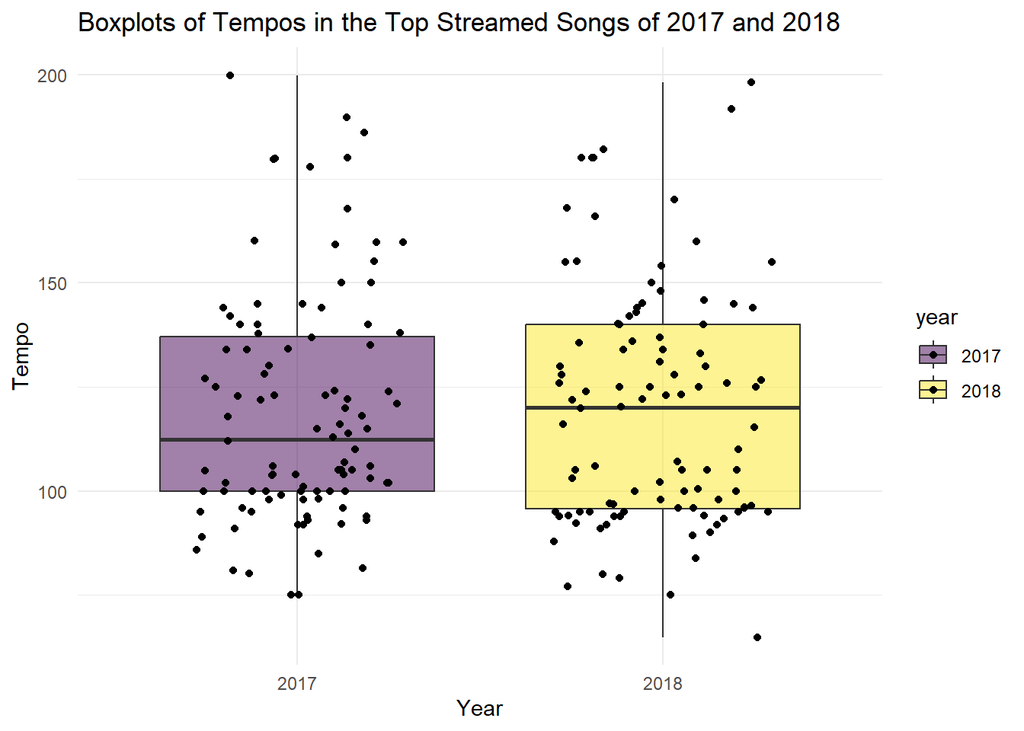

##### Model

There are two independent samples of songs, one for 2017 and the other for 2018

- $X_i \sim F_1(\mu_1, \sigma_1), \quad i = 1, \ldots, n_1$
- $Y_i \sim F_2(\mu_2, \sigma_2), \quad i = 1, \ldots, n_2$

##### Hypothesis Test

$$H_0: \mu_1 = \mu_2 \\
H_a: \mu_1 < \mu_2$$

##### Summary of the T-Test:

Unpaired T Test Results

| mean_2017 | mean_2018 | t | df | pvalue |
| --- | --- | --- | --- | --- |
| 119.2025 | 119.9042 | -0.1748531 | 197.8254 | 0.4306869 |

There is no evidence from the data that the mean tempo for the top streamed songs of 2017 is different than the mean tempo for the top streamed songs of 2018 (p = 0.431, unpaired t-test, df = 197.825)

Let’s run the same unpaired t-test for 2018 and 2019:

Tempo between 2018 and 2019 for Top 5 Songs

| rank | 2018 | 2019 |
| --- | --- | --- |
| 1 | 77.169 | 116.967 |
| 2 | 75.023 | 135.128 |
| 3 | 159.847 | 89.960 |
| 4 | 140.124 | 140.048 |
| 5 | 91.030 | 136.041 |

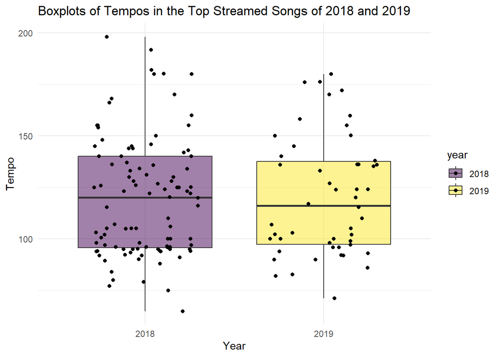

##### Model

There is two independent samples of songs, one for 2018 and the other for 2019

- $X_i \sim F_1(\mu_1, \sigma_1), \quad i = 1, \ldots, n_1$
- $Y_i \sim F_2(\mu_2, \sigma_2), \quad i = 1, \ldots, n_2$

##### Hypothesis Test

$$H_0: \mu_1 = \mu_2 \\
H_a: \mu_1 < \mu_2$$

##### Summary of the T-Test:

Unpaired T Test Results

| mean_2018 | mean_2019 | t | df | pvalue |
| --- | --- | --- | --- | --- |
| 119.9042 | 120.4257 | -0.1046967 | 98.27816 | 0.4584149 |

There is no evidence from the data that the mean tempo for the top streamed songs of 2018 is different than the mean tempo for the top streamed songs of 2019 (p = 0.458, unpaired t-test, df = 98.278)

Lastly, let’s check if there is a difference between the means for 2017 and 2019:

Tempo between 2017 and 2019 for Top 5 Songs

| rank | 2017 | 2019 |
| --- | --- | --- |
| 1 | 95.977 | 116.967 |
| 2 | 88.931 | 135.128 |
| 3 | 177.833 | 89.960 |
| 4 | 103.019 | 140.048 |
| 5 | 80.924 | 136.041 |

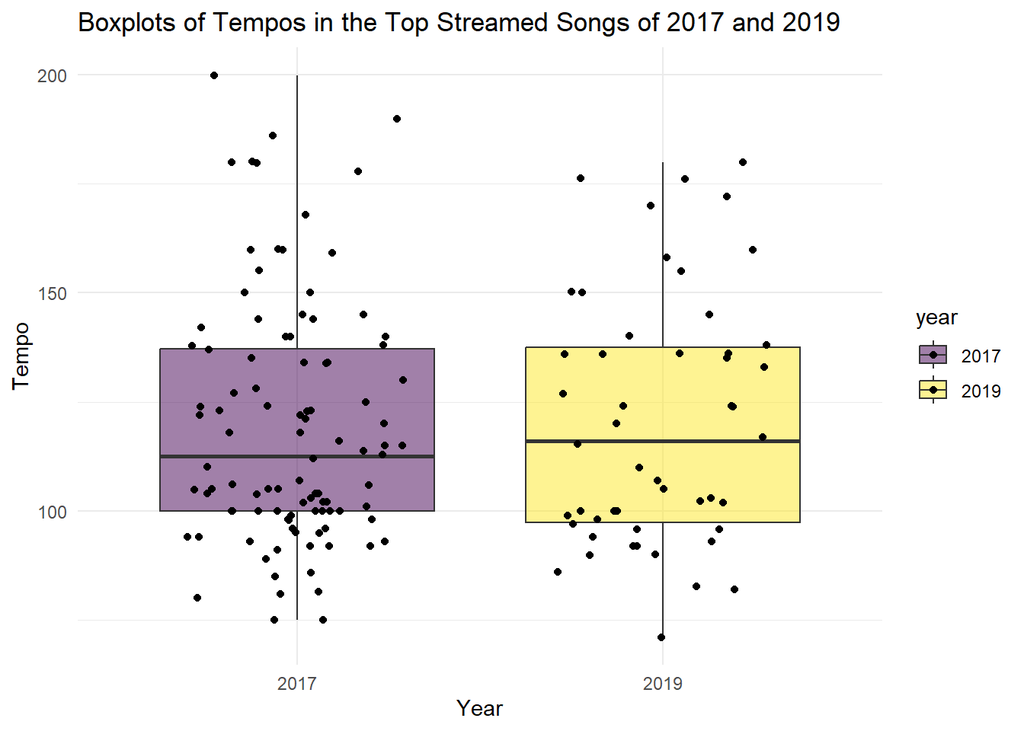

##### Model

- $X_i \sim F_1(\mu_1, \sigma_1), \quad i = 1, \ldots, n_1$
- $Y_i \sim F_2(\mu_2, \sigma_2), \quad i = 1, \ldots, n_2$

##### Hypothesis Test

$$H_0: \mu_1 = \mu_2 \\
H_a: \mu_1 < \mu_2$$

##### Summary of the T-Test:

Unpaired T Test Results

| mean_2017 | mean_2019 | t | df | pvalue |
| --- | --- | --- | --- | --- |
| 119.2025 | 120.4257 | -0.2479713 | 95.71398 | 0.4023439 |

There is no evidence from the data that the mean tempo for the top streamed songs of 2017 is different than the mean tempo for the top streamed songs of 2019 (p = 0.402, unpaired t-test, df = 95.713)

#### Correlations

Because of the results of our T-Test, we also examined the correlation between rank and tempo for each year to see if there was any relationship between the two.

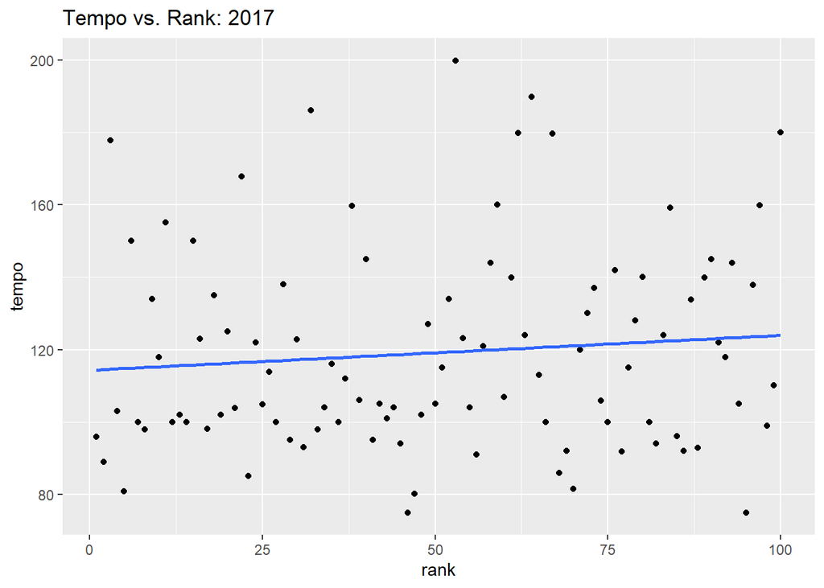

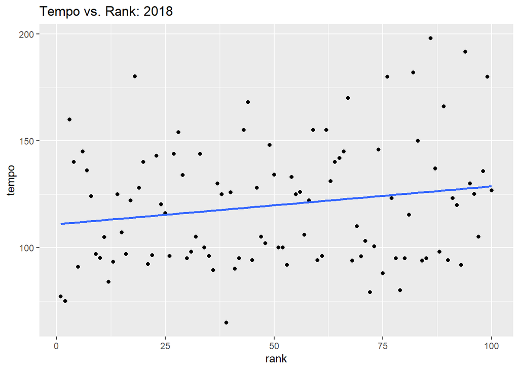

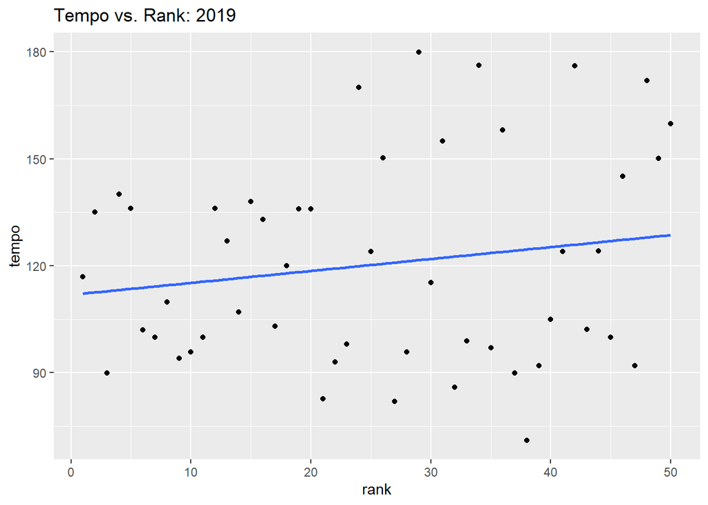

For each year the correlations were:

- 2017: $r$ = 0.100
- 2018: $r$ = 0.179
- 2019: $r$ = 0.170

### Did the top streamed songs get happier from 2017 to 2019?

Now, summarize the valence data for all three years.

Valence Summary

| year | n | mean | sd | max | min |
| --- | --- | --- | --- | --- | --- |
| 2017 | 100 | 0.517049 | 0.2164361 | 0.966 | 0.0862 |
| 2018 | 100 | 0.484443 | 0.2061452 | 0.931 | 0.0796 |
| 2019 | 50 | 0.490460 | 0.2191437 | 0.952 | 0.1200 |

- $year$ is the year the songs are from
- $n$ is the number of songs
- $mean$ is the mean valence for the given year
- $sd$ is the standard deviation of the songs’ valence
- $max$ is the song with the highest valence for the year
- $min$ is the song with the lowest valence for the year

#### T Tests

To test this, I ran an unpaired T Test (Two Mean Test) of valences between 2017 and 2018:

Valence between 2017 and 2018 for Top 5 Songs

| rank | 2017 | 2018 |
| --- | --- | --- |
| 1 | 0.931 | 0.357 |
| 2 | 0.813 | 0.473 |
| 3 | 0.846 | 0.140 |
| 4 | 0.446 | 0.439 |
| 5 | 0.811 | 0.350 |

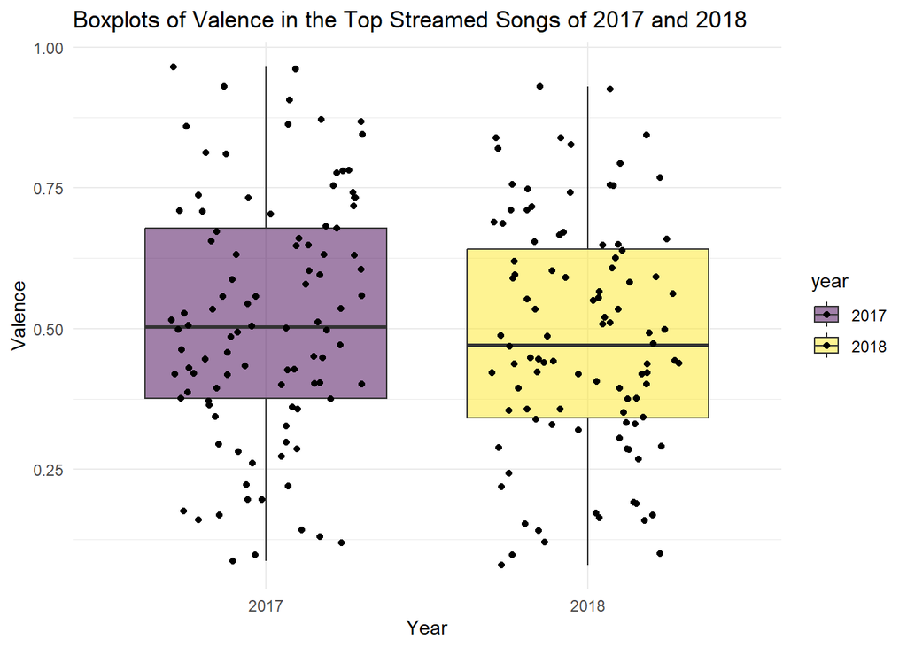

##### Model

There is two independent samples of songs, one for 2017 and the other for 2018

- $X_i \sim F_1(\mu_1, \sigma_1), \quad i = 1, \ldots, n_1$
- $Y_i \sim F_2(\mu_2, \sigma_2), \quad i = 1, \ldots, n_2$

##### Hypothesis Test

$$H_0: \mu_1 = \mu_2 \\
H_a: \mu_1 < \mu_2$$

##### Summary of the T-Test:

Unpaired T Test Results

| mean_2017 | mean_2018 | t | df | pvalue |
| --- | --- | --- | --- | --- |
| 0.517049 | 0.484443 | 1.090871 | 197.532 | 0.8616709 |

There is no evidence from the data that the mean valence for the top streamed songs of 2017 is different than the mean valence for the top streamed songs of 2018 (p = 0.862, unpaired t-test, df = 197.532)

Let’s run the same unpaired t-test for 2018 and 2019:

Valence between 2018 and 2019 for Top 5 Songs

| rank | 2018 | 2019 |
| --- | --- | --- |
| 1 | 0.357 | 0.749 |
| 2 | 0.473 | 0.562 |
| 3 | 0.140 | 0.925 |
| 4 | 0.439 | 0.327 |
| 5 | 0.350 | 0.639 |

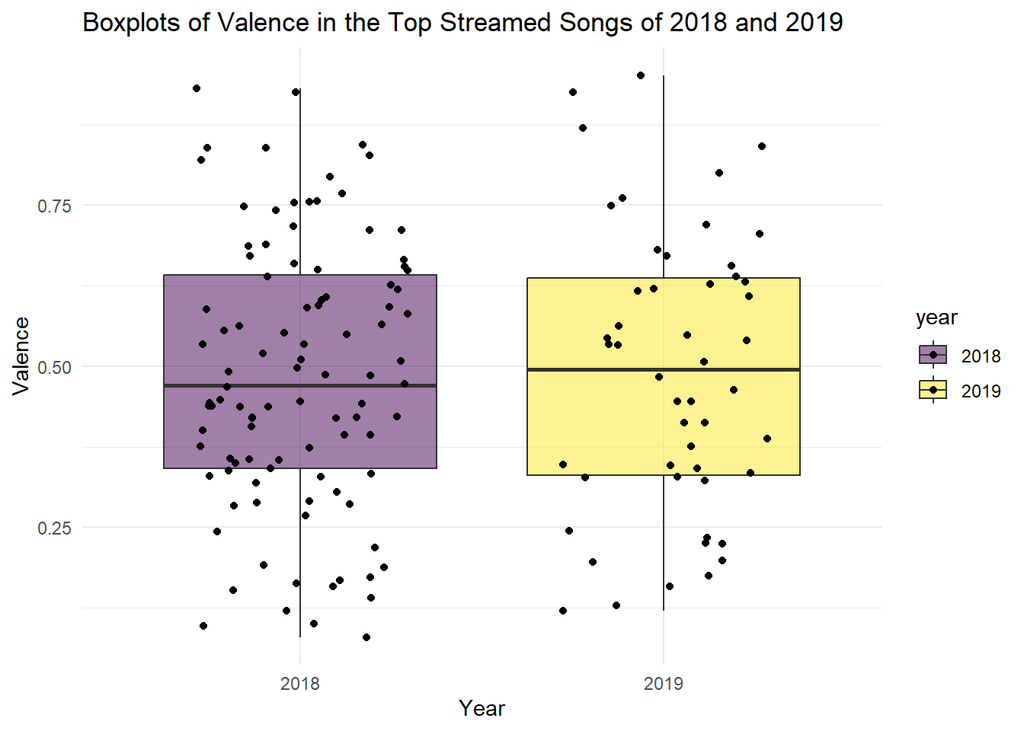

##### Model

There is two independent samples of songs, one for 2018 and the other for 2019

- $X_i \sim F_1(\mu_1, \sigma_1), \quad i = 1, \ldots, n_1$
- $Y_i \sim F_2(\mu_2, \sigma_2), \quad i = 1, \ldots, n_2$

##### Hypothesis Test

$$H_0: \mu_1 = \mu_2 \\
H_a: \mu_1 < \mu_2$$

##### Summary of the T-Test:

Unpaired T Test Results

| mean_2018 | mean_2019 | t | df | pvalue |
| --- | --- | --- | --- | --- |
| 0.484443 | 0.49046 | -0.161654 | 92.94607 | 0.4359646 |

There is no evidence from the data that the mean valence for the top streamed songs of 2018 is different than the mean valence for the top streamed songs of 2019 (p = 0.436, unpaired t-test, df = 92.946)

Lastly, let’s check if there is a difference between the means for 2017 and 2019:

Valence between 2017 and 2019 for Top 5 Songs

| rank | 2017 | 2019 |
| --- | --- | --- |
| 1 | 0.931 | 0.749 |
| 2 | 0.813 | 0.562 |
| 3 | 0.846 | 0.925 |
| 4 | 0.446 | 0.327 |
| 5 | 0.811 | 0.639 |

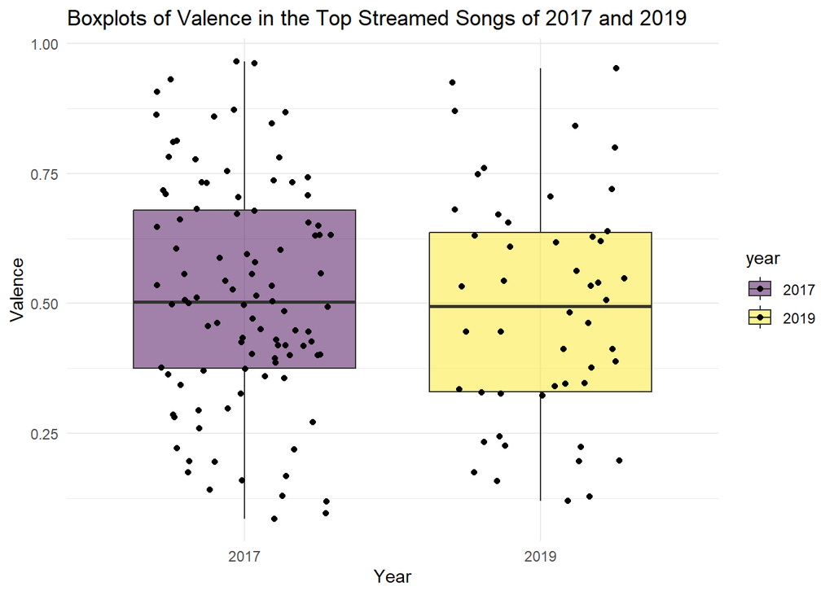

##### Model

- $X_i \sim F_1(\mu_1, \sigma_1), \quad i = 1, \ldots, n_1$
- $Y_i \sim F_2(\mu_2, \sigma_2), \quad i = 1, \ldots, n_2$

##### Hypothesis Test

$$H_0: \mu_1 = \mu_2 \\
H_a: \mu_1 < \mu_2$$

##### Summary of the T-Test:

Unpaired T Test Results

| mean_2017 | mean_2019 | t | df | pvalue |
| --- | --- | --- | --- | --- |
| 0.517049 | 0.49046 | 0.7033918 | 97.02872 | 0.758252 |

There is no evidence from the data that the mean valence for the top streamed songs of 2017 is different than the mean valence for the top streamed songs of 2019 (p = 0.758, unpaired t-test, df = 97.029)

#### Correlations

Because of the results of our T-Test, I also examined the correlation between rank and valence for each year to see if there was any relationship between the two.

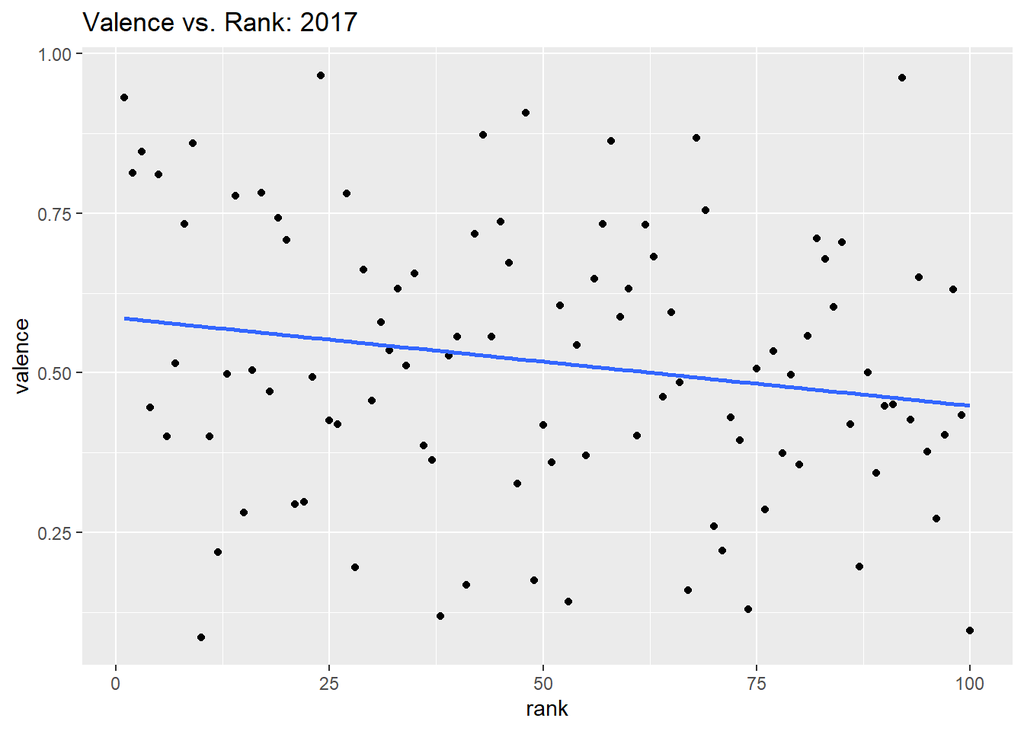

[figure not shown]

[figure not shown]

For each year the correlations were:

- 2017: $r$ = -0.185
- 2018: $r$ = 0.013
- 2019: $r$ = -0.191

## Discussion

This analysis did not find statistically significant evidence that either the tempo or valence of Spotify’s top-streamed songs increased from 2017 to 2019. Although it may feel like popular music has become faster or more upbeat in recent years, this perception was not supported by the data in this timeframe.

Several limitations and assumptions may have impacted the reliability of these findings.

#### Data accuracy

-Spotify’s audio features, including tempo and valence, are generated through proprietary machine learning models. These values are not directly measured but inferred, and the specific methodology is not publicly available.

-Abstract musical traits such as “happiness” (valence) are subjective and may not be precisely captured by the algorithm.

#### Missing key data

-Only the top 50 songs were available for 2019, compared to the top 100 songs for 2017 and 2018. This inconsistency reduces the ability to make valid comparisons across years.

-A complete dataset with an equal number of songs across all years would improve comparability and statistical power.

#### Sample not representative

-This analysis focuses on a short, consecutive three-year window. As a result, it may not reflect broader or longer-term musical trends.

-Studying a wider span (e.g., over a decade) or selecting non-consecutive years may provide a more accurate view of how musical preferences evolve.

#### Key assumptions may not hold

-Many statistical techniques assume that features like tempo and valence follow a normal distribution, which may not be true in practice.

-The relationship between musical features and rank could be non-linear, or influenced by other unobserved variables such as artist recognition, genre, or social media influence.

-These three years may not be representative of longer-term patterns in music consumption during the streaming era.

### Future Direction

To build upon this project, several improvements and extensions can be considered:

-Increase the time range to cover a broader period (e.g., 2010–2023) to detect longer-term trends in tempo and valence.

-Add more features such as danceability, energy, acousticness, and speechiness to better understand the attributes of popular songs.

-Ensure balanced sample sizes for each year (e.g., consistently using the top 100 songs) to improve comparability.

-Explore advanced models, such as regression or clustering, to identify more complex relationships between features and song popularity.

-Incorporate external context, such as cultural trends, artist popularity, or viral events, which may influence what becomes popular.

[^1]: Dataset for 2017: (https://www.kaggle.com/nadintamer/top-tracks-of-2017)
[^2]: Dataset for 2018: (https://www.kaggle.com/nadintamer/top-spotify-tracks-of-2018)
[^3]: Dataset for 2019: (https://www.kaggle.com/nadintamer/top-spotify-tracks-of-2019)